# Diversity project actual analyses I swear

We will finally analyse this data properly.

After discussion with Amanda, we’ll be using the strictestRace/Geography assignments, see `06_revisiting_population_terms` for more context on what this means.

```r
# First we clean up the plotting labels:
allSRAFinal <- allSRAFinal %>%
    mutate(strictestRace = gsub("or ", "or\n", strictestRace)) %>%
    mutate(strictestGeography = gsub("and ", "and\n", strictestGeography)) %>%
    mutate(strictestGeography = gsub("^Asia$", "Asia (NOS)", strictestGeography)) %>%
    mutate(strictestGeography = gsub("Subsaharan", "Sub-Saharan", strictestGeography)) %>%
    mutate(hispanic = gsub("^hispanic$", "Hispanic", hispanic)) %>%
    mutate(finalOrgan = gsub("^cancer$", "Cancer sample\n(NOS)", finalOrgan)) %>%
    mutate(finalSystem = gsub("^cancer$", "Cancer sample\n(NOS)", finalSystem)) %>%
    as.data.frame()

# For moving columns to upper case, because I forgot...
firstup <- function(x) {
  substr(x, 1, 1) <- toupper(substr(x, 1, 1))
  x
}

allSRAFinal$finalDisease <- firstup(allSRAFinal$finalDisease)
allSRAFinal$finalOrgan <- firstup(allSRAFinal$finalOrgan)
allSRAFinal$finalSystem <- firstup(allSRAFinal$finalSystem)

# Hispanic label trumps any other label
allSRAFinal$backupRace <- allSRAFinal$strictestRace
allSRAFinal$backupHispanic <- allSRAFinal$hispanic
allSRAFinal <- allSRAFinal %>% mutate(hispanic = na_if(hispanic, "non.hispanic"))
allSRAFinal$strictestRace <- coalesce(allSRAFinal$hispanic, allSRAFinal$strictestRace)
allSRAFinal$strictestRace <- factor(allSRAFinal$strictestRace)

# Now let's sort out some colour schemes... For Race we simply use Dark2 but we need to keep the mapping consistent, but for Geography we are following Alicia Martin and using a somewhat custom palette that doesn't follow anything standard, and then adding some new colours of our own; I opened a paper in Affinity and grabbed the html values and then added a couple for the new entries (Southeast Asia, Asia NOS):

allSRAFinal$strictestGeography <- factor(allSRAFinal$strictestGeography, levels = c("Sub-Saharan Africa", "North Africa and\nWestern Asia", "Europe", "South Asia", "Southeast Asia", "East Asia", "Asia (NOS)", "Oceania", "Americas", "Multiple", "Other"))

scale_fill_geography <- function(...){
    ggplot2:::manual_scale('fill',
        values = setNames(c('#9C8DC3', '#F3D78A', '#DB6968', '#60BC55', '#BCCC45', '#4D97CD', '#04C3C8', '#C69C3A', '#F8984E', '#8B96AD', '#FBC9C4'), levels(allSRAFinal$strictestGeography)),
    )
}

scale_color_geography <- function(...){
    ggplot2:::manual_scale('color',
        values = setNames(c('#9C8DC3', '#F3D78A', '#DB6968', '#60BC55', '#BCCC45', '#4D97CD', '#04C3C8', '#C69C3A', '#F8984E', '#8B96AD', '#FBC9C4'), levels(allSRAFinal$strictestGeography)),
    )
}

raceColours <- brewer.pal(8,"Set2") #8 because we don't plot NAs

scale_color_race <- function(...){
    ggplot2:::manual_scale('color',
                           values = setNames(raceColours, levels(allSRAFinal$strictestRace)),
    )
}

scale_fill_race <- function(...){
    ggplot2:::manual_scale('fill',
        values = setNames(raceColours, levels(allSRAFinal$strictestRace)),
    )
}

wberCols <- c(viridis::turbo(n = 7))
scale_fill_wber <- function(...){
    ggplot2:::manual_scale('fill',
        values = setNames(wberCols, c("East Asia &\nPacific", "Europe &\nCentral Asia", "Latin America &\nCaribbean", "Middle East &\nNorth Africa", "North America", "South Asia", "Sub-Saharan Africa")), na.value = "grey50")
}


# We also define a couple of plot layouts:
long2Design <- "
  12
  12
"
wide2Design <- "
  11
  22
"

theme_set(theme_bw(base_size = 6))
theme_update(axis.text=element_text(size=7))
theme_update(legend.key.size = unit(12, 'pt'), #change legend key size
        legend.title = element_text(size=8), #change legend title font size
        legend.text = element_text(size=6),
        plot.title = element_text(size=8))
theme_update(plot.margin = unit(c(0, 0, 0, 0), "pt"))
```

We’re also going to use some additional info from the World Bank, so let’s add those columns in now:

```r
worldBank <- read.csv("World_Bank_Descriptors.csv")

# Some names need to be fixed, but others are more flexible? I'd rather have USA than United States.
allSRAFinal$finalCountry <- gsub("^UK$", "United Kingdom", allSRAFinal$finalCountry)
allSRAFinal$finalCountry <- gsub("^Korea$", "South Korea", allSRAFinal$finalCountry)

allSRAFinal$worldBank <- worldBank[match(allSRAFinal$finalCountry, worldBank$Economy),]$Income.group
# allSRAFinal %>% count(finalCountry, worldBank)

# Missing countries are all high income, so we can set them to that manually now that we're happy with the names:
allSRAFinal <- allSRAFinal %>%
  mutate(worldBank = if_else(is.na(worldBank), "High income", worldBank)) %>%
  mutate(worldBank = if_else(is.na(finalCountry), NA, worldBank ))

# And now the regions they define:
allSRAFinal$worldRegion <- worldBank[match(allSRAFinal$finalCountry, worldBank$Economy),]$Region
# allSRAFinal %>% count(finalCountry, worldRegion)

# Once again we gotta add some manually...
allSRAFinal <- allSRAFinal %>%
  mutate(worldRegion = if_else(grepl("Russia|Slovakia", finalCountry), "Europe & Central Asia", worldRegion)) %>%
  mutate(worldRegion = if_else(grepl("South Korea|Taiwan", finalCountry), "East Asia & Pacific", worldRegion)) %>%
  mutate(worldRegion = if_else(grepl("USA", finalCountry), "North America", worldRegion)) %>%
  as.data.frame()

# And now we need to clean up some labels so we can plot them better. Good thing is, it's just an ampersand:
allSRAFinal$worldRegion <- gsub("& ", "&\n", allSRAFinal$worldRegion)
```

## 1. Who is being sequenced?

```r
geographyProp <- allSRAFinal %>% drop_na(strictestGeography) %>% count(strictestGeography) %>% mutate(freq = n/sum(n))
raceProp <- allSRAFinal %>% drop_na(strictestRace) %>% count(strictestRace) %>% mutate(freq = n/sum(n))

geoPlot <- ggplot(geographyProp, aes(x = fct_inorder(strictestGeography), y = n, fill = strictestGeography)) +
  geom_bar(stat="identity") +
  ggtitle("Submitted descriptor\n(ancestral/geographic origin)") +
  xlab("") +
  ylab("Samples") +
  coord_flip() +
  scale_fill_geography() +
  theme(axis.text.x = element_text(angle = 45, hjust=1)) +
  theme(legend.position="none")

geographyProp
```

```
##                strictestGeography    n        freq
## 1              Sub-Saharan Africa 1694 0.172417303
## 2  North Africa and\nWestern Asia   18 0.001832061
## 3                          Europe 5469 0.556641221
## 4                      South Asia  718 0.073078880
## 5                  Southeast Asia   49 0.004987277
## 6                       East Asia 1121 0.114096692
## 7                      Asia (NOS)  310 0.031552163
## 8                         Oceania   11 0.001119593
## 9                        Americas  166 0.016895674
## 10                       Multiple  207 0.021068702
## 11                          Other   62 0.006310433
```

```r
sum(geographyProp$n)
```

```
## [1] 9825
```

```r
racePlot <- ggplot(raceProp, aes(x = fct_inorder(strictestRace), y = n, fill=strictestRace)) +
  geom_bar(stat="identity") +
  ggtitle("Submitted descriptor\n(US Census term)") +
  xlab("") +
  ylab("Samples") +
  coord_flip() +
  scale_fill_race() +
  theme(axis.text.x = element_text(angle = 45, hjust=1)) +
  theme(legend.position="none")

raceProp
```

```
##                                 strictestRace    n         freq
## 1          American Indian and\nAlaska Native   43 0.0030594095
## 2                                       Asian  944 0.0671647101
## 3                  Black or\nAfrican American 1742 0.1239416578
## 4                                    Hispanic 1255 0.0892920669
## 5                                    Multiple  203 0.0144432586
## 6 Native Hawaiian and\nother Pacific Islander    6 0.0004268943
## 7                                       Other  162 0.0115261473
## 8                                       White 9700 0.6901458556
```

```r
sum(raceProp$n)
```

```
## [1] 14055
```

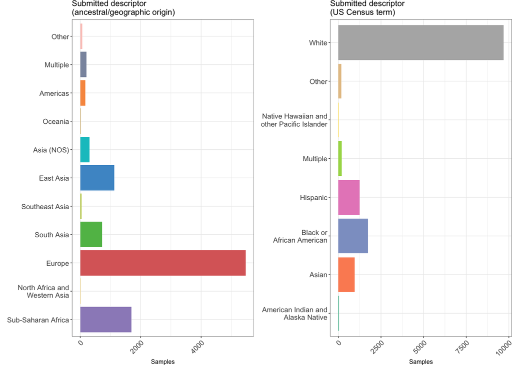

```r
geoPlot + racePlot +
    plot_layout(design = long2Design)
```

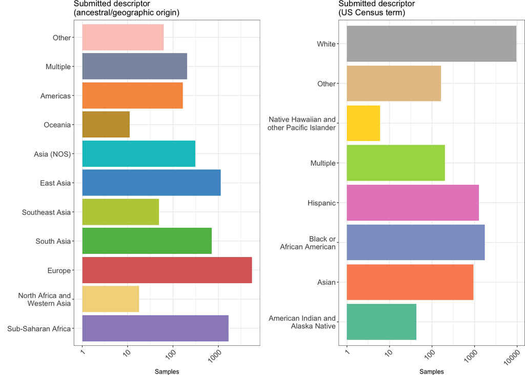

```r
ggsave("fig1_overall.pdf")
# And now with log transform on the axis:
geoPlot <- geoPlot +
  scale_y_continuous(trans='log10')
racePlot <- racePlot +
  scale_y_continuous(trans='log10')

geoPlot + racePlot +
    plot_layout(design = long2Design)
```

```r
ggsave("fig1_overall_log10.pdf")
# There's 132 samples that do not have any info besides "Not Hispanic", which I think we should treat as NA, and therefore drop. The other option is to change them to race: Other and then move on with our lives.
allSRAFinal %>% filter(is.na(allSRAFinal$strictestGeography) & is.na(allSRAFinal$strictestRace)) %>% count(ETHNICITY, RACE)
```

```
##                           ETHNICITY                              RACE  n
## 1 American indian or alaskan native                              <NA> 14
## 2                      Non-Hispanic                              <NA> 36
## 3            Not Hispanic or Latino           Unknown or Not Reported  4
## 4            Not Hispanic or Latino                              <NA> 92
## 5                              <NA> American Indian or Alaskan Native  2
```

```r
allSRAFinal <- allSRAFinal %>% filter(!is.na(allSRAFinal$strictestGeography) | !is.na(allSRAFinal$strictestRace))

nrow(allSRAFinal[!is.na(allSRAFinal$strictestGeography) | !is.na(allSRAFinal$strictestRace),])
```

```
## [1] 23880
```

```r
dim(allSRAFinal)
```

```
## [1] 23880    49
```

All samples accounted for now, at last!

So let’s get a bit more granular, showing n samples per study:

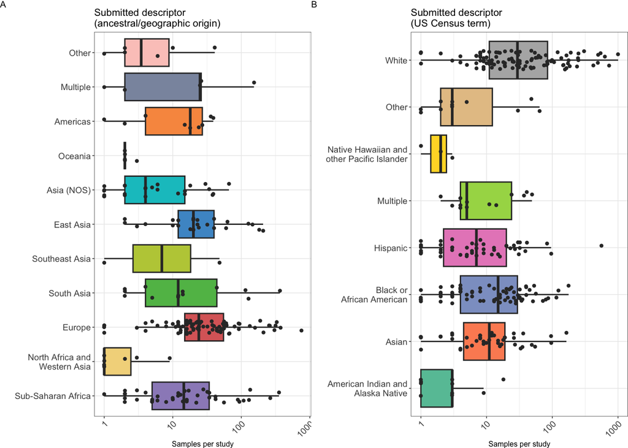

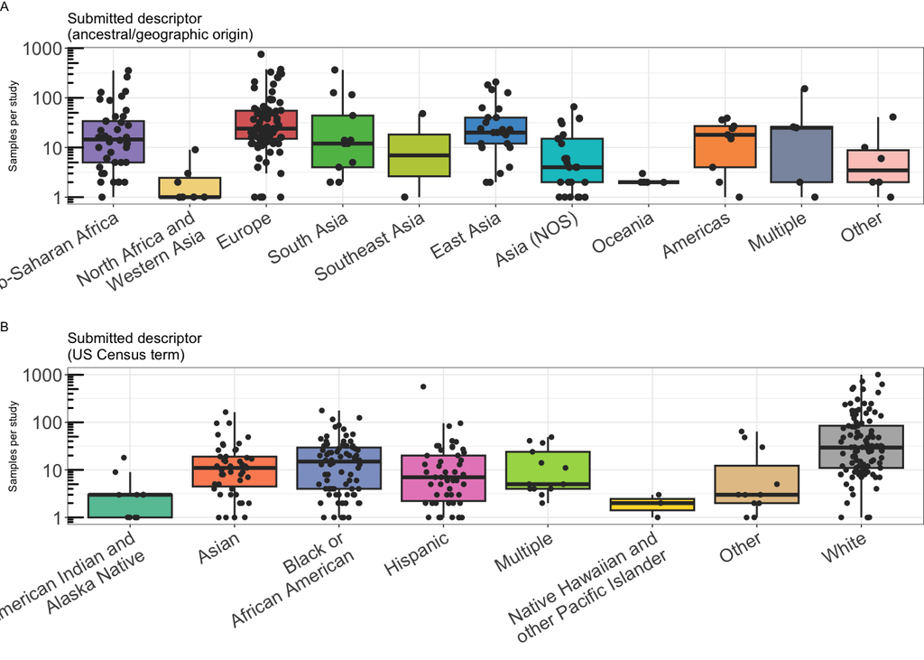

Let’s get some meaningful statistics on this:

First we separate studies on the basis of whether they contain racial or geographic descriptors, but the hispanic usage introduces a new complexity… There’s a bunch of studies that now straddle the two categories. Could shift them to race like we did before, but better to just leave them alone for now? I am overthinking.

```r
geographyClean <- allSRAFinal %>% drop_na(strictestGeography)
raceClean <- allSRAFinal %>% drop_na(strictestRace)

geoSRA <- unique(geographyClean$SRA.Study)
length(geoSRA)
```

```
## [1] 135
```

```r
raceSRA <- unique(raceClean$SRA.Study)
length(raceSRA)
```

```
## [1] 139
```

```r
length(intersect(geoSRA, raceSRA))
```

```
## [1] 13
```

```r
allSRAFinal %>% filter(grepl(paste(intersect(geoSRA, raceSRA), collapse="|"), SRA.Study)) %>%
  group_by(SRA.Study) %>%
  summarise(size = n(), studyJoint = n_distinct(SRA.Study))
```

```
## # A tibble: 13 × 3
##    SRA.Study  size studyJoint
##    <chr>     <int>      <int>
##  1 DRP001797    42          1
##  2 SRP070663    12          1
##  3 SRP086245    42          1
##  4 SRP108559    32          1
##  5 SRP172694     6          1
##  6 SRP216947    36          1
##  7 SRP221484   195          1
##  8 SRP245400   345          1
##  9 SRP274641     6          1
## 10 SRP283115    17          1
## 11 SRP303641   100          1
## 12 SRP374111   100          1
## 13 SRP388678   492          1
```

```r
allSRAFinal %>% filter(grepl(paste(intersect(geoSRA, raceSRA), collapse="|"), SRA.Study)) %>% nrow()
```

```
## [1] 1425
```

```r
# Diversity by study:
geographyClean %>% group_by(SRA.Study) %>%
  summarise(size = n(), studyGeo = n_distinct(strictestGeography)) %>%
  summarise(n = size, meanSize = mean(size), meanGeo = mean(studyGeo), maxSize = max(size), maxGeo = max(studyGeo), sdSize = sd(size), sdGeo = sd(studyGeo))
```

```
## # A tibble: 135 × 7
##        n meanSize meanGeo maxSize maxGeo sdSize sdGeo
##    <int>    <dbl>   <dbl>   <int>  <int>  <dbl> <dbl>
##  1    40     72.8    1.67     753      6   128.  1.15
##  2   464     72.8    1.67     753      6   128.  1.15
##  3   332     72.8    1.67     753      6   128.  1.15
##  4    51     72.8    1.67     753      6   128.  1.15
##  5   133     72.8    1.67     753      6   128.  1.15
##  6    66     72.8    1.67     753      6   128.  1.15
##  7    20     72.8    1.67     753      6   128.  1.15
##  8   159     72.8    1.67     753      6   128.  1.15
##  9    44     72.8    1.67     753      6   128.  1.15
## 10   181     72.8    1.67     753      6   128.  1.15
## # ℹ 125 more rows
```

```r
raceClean %>% group_by(SRA.Study) %>%
  summarise(size = n(), studyRace = n_distinct(strictestRace)) %>%
  summarise(n = size, meanSize = mean(size), meanRace = mean(studyRace), maxSize = max(size), maxRace = max(studyRace), sdSize = sd(size), sdRace = sd(studyRace))
```

```
## # A tibble: 139 × 7
##        n meanSize meanRace maxSize maxRace sdSize sdRace
##    <int>    <dbl>    <dbl>   <int>   <int>  <dbl>  <dbl>
##  1     2     101.     2.26    1857       8   213.   1.44
##  2    36     101.     2.26    1857       8   213.   1.44
##  3    13     101.     2.26    1857       8   213.   1.44
##  4    20     101.     2.26    1857       8   213.   1.44
##  5    95     101.     2.26    1857       8   213.   1.44
##  6    37     101.     2.26    1857       8   213.   1.44
##  7     9     101.     2.26    1857       8   213.   1.44
##  8    10     101.     2.26    1857       8   213.   1.44
##  9    12     101.     2.26    1857       8   213.   1.44
## 10   113     101.     2.26    1857       8   213.   1.44
## # ℹ 129 more rows
```

```r
# By descriptor across all studies
geographyClean %>% group_by(SRA.Study) %>% count(strictestGeography) %>% group_by(strictestGeography) %>%
  summarise(size = sum(n), studyGeo = n_distinct(SRA.Study), mean = mean(n), max = max(n), sd = sd(n))
```

```
## # A tibble: 11 × 6
##    strictestGeography                size studyGeo  mean   max      sd
##    <fct>                            <int>    <int> <dbl> <int>   <dbl>
##  1 "Sub-Saharan Africa"              1694       42 40.3    355  70.7
##  2 "North Africa and\nWestern Asia"    18        7  2.57     9   2.94
##  3 "Europe"                          5469       87 62.9    753 109.
##  4 "South Asia"                       718       13 55.2    365 102.
##  5 "Southeast Asia"                    49        2 24.5     48  33.2
##  6 "East Asia"                       1121       25 44.8    208  57.5
##  7 "Asia (NOS)"                       310       25 12.4     66  16.6
##  8 "Oceania"                           11        5  2.2      3   0.447
##  9 "Americas"                         166        9 18.4     39  14.3
## 10 "Multiple"                         207        5 41.4    153  63.5
## 11 "Other"                             62        6 10.3     41  15.4
```

```r
raceClean %>% group_by(SRA.Study) %>% count(strictestRace) %>% group_by(strictestRace) %>%
  summarise(size = sum(n), studyRace = n_distinct(SRA.Study), mean = mean(n), max = max(n), sd = sd(n))
```

```
## # A tibble: 8 × 6
##   strictestRace                                  size studyRace  mean   max     sd
##   <fct>                                         <int>     <int> <dbl> <int>  <dbl>
## 1 "American Indian and\nAlaska Native"             43        10   4.3    18   5.38
## 2 "Asian"                                         944        47  20.1   164  29.9
## 3 "Black or\nAfrican American"                   1742        74  23.5   177  30.9
## 4 "Hispanic"                                     1255        50  25.1   562  79.8
## 5 "Multiple"                                      203        13  15.6    49  16.5
## 6 "Native Hawaiian and\nother Pacific Islander"     6         3   2       3   1
## 7 "Other"                                         162        11  14.7    64  22.3
## 8 "White"                                        9700       106  91.5  1005 162.
```

## 2. And by who? Where is the sequencing happening?

There are many ways to slice this, but some are harder to see than others, so here is the final best attempt…

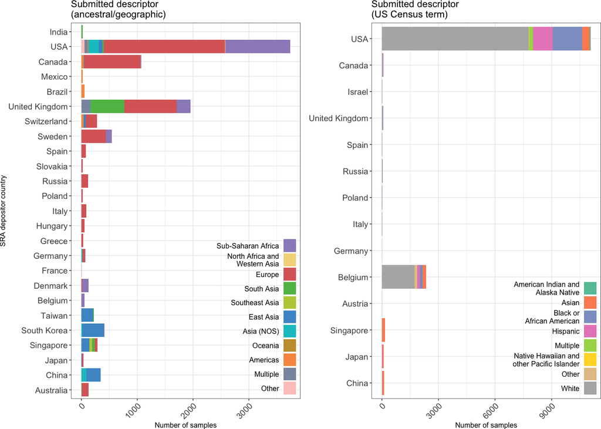

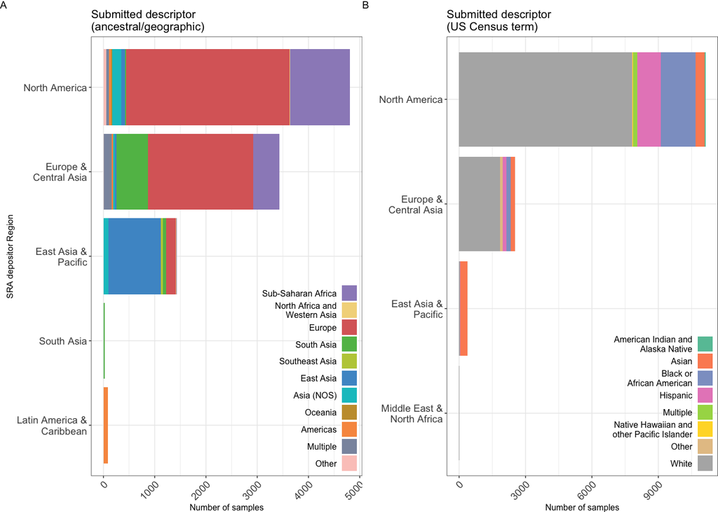

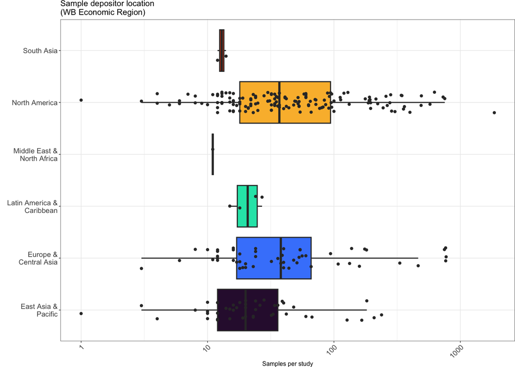

Some nice statistics about all of this:

```r
# By study by world region:
geographyClean %>% group_by(worldRegion, SRA.Study) %>%
  summarise(size = n(), studyGeo = n_distinct(strictestGeography)) %>%
  summarise(n = n(), meanSize = mean(size), meanGeo = mean(studyGeo), maxSize = max(size), maxGeo = max(studyGeo), sdSize = sd(size), sdGeo = sd(studyGeo))
```

```
## # A tibble: 6 × 8
##   worldRegion                      n meanSize meanGeo maxSize maxGeo sdSize sdGeo
##   <chr>                        <int>    <dbl>   <dbl>   <int>  <int>  <dbl> <dbl>
## 1 "East Asia &\nPacific"          32     44.6    1.31     238      5  59.2  0.931
## 2 "Europe &\nCentral Asia"        40     85.9    1.4      748      4 141.   0.810
## 3 "Latin America &\nCaribbean"     4     21      1         27      1   5.48 0
## 4 "North America"                 54     89.1    2.17     753      6 152.   1.37
## 5 "South Asia"                     2     13      2         14      3   1.41 1.41
## 6  <NA>                            3     13.3    1         18      1   5.03 0
```

```r
raceClean %>% group_by(worldRegion, SRA.Study) %>%
  summarise(size = n(), studyRace = n_distinct(strictestRace)) %>%
  summarise(n = n(), meanSize = mean(size), meanRace = mean(studyRace), maxSize = max(size), maxRace = max(studyRace), sdSize = sd(size), sdRace = sd(studyRace))
```

```
## # A tibble: 4 × 8
##   worldRegion                       n meanSize meanRace maxSize maxRace sdSize sdRace
##   <chr>                         <int>    <dbl>    <dbl>   <int>   <int>  <dbl>  <dbl>
## 1 "East Asia &\nPacific"           14     27.6     1.36     166       4   40.9  0.842
## 2 "Europe &\nCentral Asia"         14    180       2.43     772       5  319.   1.45
## 3 "Middle East &\nNorth Africa"     1     11       1         11       1   NA   NA
## 4 "North America"                 110    101.      2.36    1857       8  209.   1.47
```

```r
# By descriptor by economic region
geographyClean %>% group_by(SRA.Study, worldRegion) %>% count(strictestGeography) %>% group_by(worldRegion, strictestGeography) %>%
  summarise(size = sum(n), studyGeo = n_distinct(SRA.Study), mean = mean(n), max = max(n), sd = sd(n)) %>%
  as.data.frame()
```

```
##                   worldRegion             strictestGeography size studyGeo       mean max          sd
## 1        East Asia &\nPacific             Sub-Saharan Africa    9        2   4.500000   8   4.9497475
## 2        East Asia &\nPacific North Africa and\nWestern Asia    3        1   3.000000   3          NA
## 3        East Asia &\nPacific                         Europe  191        8  23.875000  61  21.1351941
## 4        East Asia &\nPacific                     South Asia   60        3  20.000000  44  21.6333077
## 5        East Asia &\nPacific                 Southeast Asia   49        2  24.500000  48  33.2340187
## 6        East Asia &\nPacific                      East Asia 1016       22  46.181818 208  60.6360229
## 7        East Asia &\nPacific                     Asia (NOS)  100        4  25.000000  39  13.4907376
## 8      Europe &\nCentral Asia             Sub-Saharan Africa  516       10  51.600000 129  42.8205558
## 9      Europe &\nCentral Asia                         Europe 2051       32  64.093750 375  91.6058737
## 10     Europe &\nCentral Asia                     South Asia  611        5 122.200000 365 148.2588952
## 11     Europe &\nCentral Asia                      East Asia   40        1  40.000000  40          NA
## 12     Europe &\nCentral Asia                     Asia (NOS)   23        3   7.666667  18   9.0737717
## 13     Europe &\nCentral Asia                       Americas   40        2  20.000000  39  26.8700577
## 14     Europe &\nCentral Asia                       Multiple  153        1 153.000000 153          NA
```

[output cut: 16 more lines]

```r
raceClean %>% group_by(SRA.Study, worldRegion) %>% count(strictestRace) %>% group_by(worldRegion, strictestRace) %>%
  summarise(size = sum(n), studyRace = n_distinct(SRA.Study), mean = mean(n), max = max(n), sd = sd(n)) %>%
  as.data.frame()
```

```
##                    worldRegion                               strictestRace size studyRace      mean  max         sd
## 1         East Asia &\nPacific          American Indian and\nAlaska Native    3         1   3.00000    3         NA
## 2         East Asia &\nPacific                                       Asian  338        11  30.72727  164  44.884498
## 3         East Asia &\nPacific                  Black or\nAfrican American    2         1   2.00000    2         NA
## 4         East Asia &\nPacific                                    Hispanic   14         2   7.00000   12   7.071068
## 5         East Asia &\nPacific                                       White   29         4   7.25000   13   5.123475
## 6       Europe &\nCentral Asia          American Indian and\nAlaska Native    3         1   3.00000    3         NA
## 7       Europe &\nCentral Asia                                       Asian  194         4  48.50000   96  54.848276
## 8       Europe &\nCentral Asia                  Black or\nAfrican American  175         9  19.44444   80  25.884895
## 9       Europe &\nCentral Asia                                    Hispanic  167         5  33.40000   96  37.825917
## 10      Europe &\nCentral Asia                                       Other  142         3  47.33333   64  17.009801
## 11      Europe &\nCentral Asia                                       White 1839        12 153.25000  630 244.541547
## 12 Middle East &\nNorth Africa                                       White   11         1  11.00000   11         NA
## 13               North America          American Indian and\nAlaska Native   37         8   4.62500   18   6.045955
## 14               North America                                       Asian  412        32  12.87500   55  13.689530
## 15               North America                  Black or\nAfrican American 1565        64  24.45312  177  31.828873
## 16               North America                                    Hispanic 1074        43  24.97674  562  85.245161
## 17               North America                                    Multiple  203        13  15.61538   49  16.545586
## 18               North America Native Hawaiian and\nother Pacific Islander    6         3   2.00000    3   1.000000
## 19               North America                                       Other   20         8   2.50000    5   1.309307
## 20               North America                                       White 7821        89  87.87640 1005 151.443495
```

```r
allSRAFinal %>% filter(!is.na(worldBank)) %>% count(worldBank) %>% mutate(freq = n/sum(n)) %>% arrange(desc(freq))
```

```
##             worldBank     n        freq
## 1         High income 23266 0.975922819
## 2 Upper middle income   548 0.022986577
## 3 Lower middle income    26 0.001090604
```

```r
allSRAFinal %>% filter(!is.na(finalCountry)) %>% count(finalCountry) %>% mutate(freq = n/sum(n)) %>% arrange(desc(freq))
```

```
##      finalCountry     n         freq
## 1             USA 14804 0.6209731544
## 2         Belgium  2413 0.1012164430
## 3  United Kingdom  2018 0.0846476510
## 4          Canada  1144 0.0479865772
## 5          Sweden   540 0.0226510067
## 6           China   464 0.0194630872
## 7       Singapore   452 0.0189597315
## 8     South Korea   411 0.0172399329
## 9     Switzerland   278 0.0116610738
## 10         Taiwan   222 0.0093120805
## 11         Russia   166 0.0069630872
## 12          Japan   139 0.0058305369
## 13      Australia   126 0.0052852349
## 14        Denmark   124 0.0052013423
## 15          Italy    99 0.0041526846
## 16          Spain    91 0.0038171141
## 17        Germany    78 0.0032718121
## 18         Brazil    57 0.0023909396
## 19        Hungary    54 0.0022651007
## 20         Poland    34 0.0014261745
## 21         Greece    28 0.0011744966
## 22         Mexico    27 0.0011325503
## 23          India    26 0.0010906040
## 24       Slovakia    23 0.0009647651
## 25         Israel    11 0.0004614094
## 26        Austria     8 0.0003355705
## 27         France     3 0.0001258389
```

```r
allSRAFinal %>% filter(!is.na(strictestGeography)) %>% count(worldBank) %>% mutate(freq = n/sum(n)) %>% arrange(desc(freq))
```

```
##             worldBank    n        freq
## 1         High income 9332 0.949821883
## 2 Upper middle income  427 0.043460560
## 3                <NA>   40 0.004071247
## 4 Lower middle income   26 0.002646310
```

```r
allSRAFinal %>% filter(!is.na(strictestRace)) %>% count(worldBank) %>% mutate(freq = n/sum(n)) %>% arrange(desc(freq))
```

```
##             worldBank     n        freq
## 1         High income 13934 0.991390964
## 2 Upper middle income   121 0.008609036
```

```r
allSRAFinal %>% filter(!is.na(strictestGeography)) %>% count(finalCountry) %>% mutate(freq = n/sum(n)) %>% arrange(desc(freq))
```

```
##      finalCountry    n         freq
## 1             USA 3738 0.3804580153
## 2  United Kingdom 1951 0.1985750636
## 3          Canada 1072 0.1091094148
## 4          Sweden  540 0.0549618321
## 5     South Korea  411 0.0418320611
## 6           China  343 0.0349109415
## 7       Singapore  286 0.0291094148
## 8     Switzerland  278 0.0282951654
## 9          Taiwan  222 0.0225954198
## 10      Australia  126 0.0128244275
## 11        Denmark  124 0.0126208651
## 12         Russia  118 0.0120101781
## 13          Italy   87 0.0088549618
## 14          Spain   79 0.0080407125
## 15        Germany   72 0.0073282443
## 16         Brazil   57 0.0058015267
## 17        Belgium   56 0.0056997455
## 18        Hungary   54 0.0054961832
## 19          Japan   40 0.0040712468
## 20           <NA>   40 0.0040712468
## 21         Greece   28 0.0028498728
## 22         Mexico   27 0.0027480916
## 23          India   26 0.0026463104
## 24         Poland   24 0.0024427481
## 25       Slovakia   23 0.0023409669
## 26         France    3 0.0003053435
```

```r
allSRAFinal %>% filter(!is.na(strictestRace)) %>% count(finalCountry) %>% mutate(freq = n/sum(n)) %>% arrange(desc(freq))
```

```
##      finalCountry     n         freq
## 1             USA 11066 0.7873354678
## 2         Belgium  2357 0.1676983280
## 3       Singapore   166 0.0118107435
## 4           China   121 0.0086090359
## 5           Japan    99 0.0070437567
## 6          Canada    72 0.0051227321
## 7  United Kingdom    67 0.0047669868
## 8          Russia    48 0.0034151547
## 9           Italy    12 0.0008537887
## 10          Spain    12 0.0008537887
## 11         Israel    11 0.0007826396
## 12         Poland    10 0.0007114906
## 13        Austria     8 0.0005691925
## 14        Germany     6 0.0004268943
```

```r
allSRAFinal %>% filter(!is.na(strictestGeography)) %>% count(worldRegion) %>% mutate(freq = n/sum(n)) %>% arrange(desc(freq))
```

```
##                  worldRegion    n        freq
## 1              North America 4810 0.489567430
## 2     Europe &\nCentral Asia 3437 0.349821883
## 3       East Asia &\nPacific 1428 0.145343511
## 4 Latin America &\nCaribbean   84 0.008549618
## 5                       <NA>   40 0.004071247
## 6                 South Asia   26 0.002646310
```

```r
allSRAFinal %>% filter(!is.na(strictestRace)) %>% count(worldRegion) %>% mutate(freq = n/sum(n)) %>% arrange(desc(freq))
```

```
##                   worldRegion     n         freq
## 1               North America 11138 0.7924581999
## 2      Europe &\nCentral Asia  2520 0.1792956243
## 3        East Asia &\nPacific   386 0.0274635361
## 4 Middle East &\nNorth Africa    11 0.0007826396
```

```r
allSRAFinal %>% count(worldRegion) %>% mutate(freq = n/sum(n)) %>% arrange(desc(freq))
```

```
##                   worldRegion     n         freq
## 1               North America 15948 0.6678391960
## 2      Europe &\nCentral Asia  5957 0.2494556114
## 3        East Asia &\nPacific  1814 0.0759631491
## 4  Latin America &\nCaribbean    84 0.0035175879
## 5                        <NA>    40 0.0016750419
## 6                  South Asia    26 0.0010887772
## 7 Middle East &\nNorth Africa    11 0.0004606365
```

```r
# And finally... are studies from certain regions bigger than others?
NAEurSizes <- allSRAFinal %>% filter(worldRegion == "North America" | worldRegion == "Europe") %>%
  count(SRA.Study)

restWorldSizes <- allSRAFinal %>% filter(worldRegion != "North America" & worldRegion != "Europe") %>%
  count(SRA.Study)

t.test(restWorldSizes$n, NAEurSizes$n)
```

```
##
##  Welch Two Sample t-test
##
## data:  restWorldSizes$n and NAEurSizes$n
## t = -1.3275, df = 251.9, p-value = 0.1855
## alternative hypothesis: true difference in means is not equal to 0
## 95 percent confidence interval:
##  -72.20593  14.05916
## sample estimates:
## mean of x mean of y
##   75.1619  104.2353
```

```r
allStudySizes <- allSRAFinal %>% group_by(SRA.Study) %>%
  summarise(sampleSize = n(), region = worldRegion) %>%
  distinct()
lm(sampleSize ~ region, data = allStudySizes)
```

```
##
## Call:
## lm(formula = sampleSize ~ region, data = allStudySizes)
##
## Coefficients:
##                       (Intercept)       regionEurope &\nCentral Asia   regionLatin America &\nCaribbean  regionMiddle East &\nNorth Africa                regionNorth America
##                             40.31                              72.09                             -19.31                             -29.31                              63.92
##                  regionSouth Asia
##                            -27.31
```

```r
anova(lm(sampleSize ~ region, data = allStudySizes))
```

```
## Analysis of Variance Table
##
## Response: sampleSize
##            Df  Sum Sq Mean Sq F value Pr(>F)
## region      5  204346   40869  1.2516 0.2855
## Residuals 252 8228480   32653
```

```r
# Note that there's an issue here - although we filtered for studies with more than 10 entries, not all of those will have 10 samples with descriptors, which explains why these numbers are smaller. So long as we are consistent across the two datasets, it should be ok.
```

Maybe worth considering some alluvial plots? At the single country level they’re very messy, however, so what about at the World Bank region level?

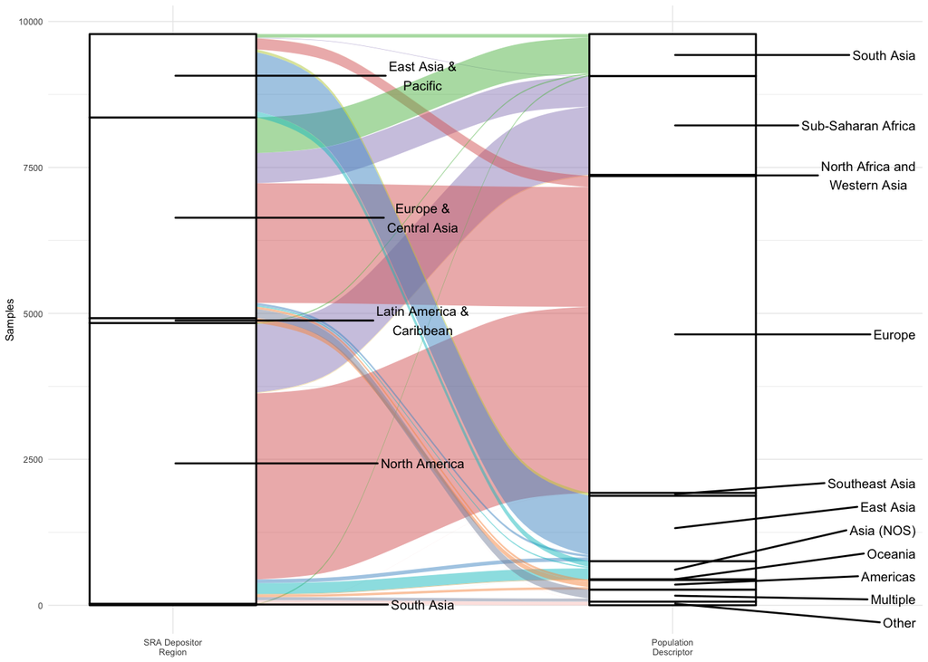

```r
allSRAFinal %>% count(strictestGeography, worldRegion) %>% drop_na(c(strictestGeography, worldRegion)) %>%
  ggplot(data = .,
         aes(axis1 = worldRegion, axis2 = strictestGeography, y = n)) +
    scale_x_discrete(limits = c("SRA Depositor\nRegion", "Population\nDescriptor"), expand = c(.2, .05)) +
    geom_alluvium(aes(fill = strictestGeography)) +
    scale_fill_geography(name="Population\nDescriptor") +
    geom_stratum(width=1/3) +
    ylab("Samples") +
    geom_text_repel(stat = "stratum", aes(label = after_stat(stratum)), size = 2.5, direction = "y", nudge_x = .5) +
    theme_minimal(base_size = 6) +
    theme(legend.position = "none")
```

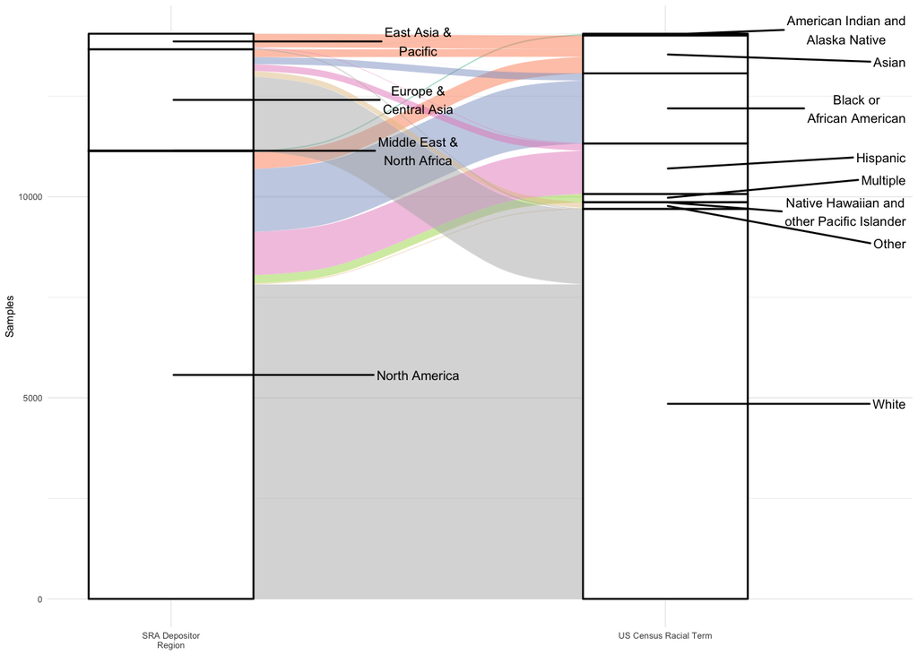

```r
allSRAFinal %>% count(strictestRace, worldRegion) %>% drop_na(c(strictestRace, worldRegion)) %>%
  ggplot(data = .,
         aes(axis1 = worldRegion, axis2 = strictestRace, y = n)) +
    scale_x_discrete(limits = c("SRA Depositor\nRegion", "US Census Racial Term"), expand = c(.2, .05)) +
    geom_alluvium(aes(fill = strictestRace)) +
    scale_fill_race(name="US Census\nTerm)") +
    geom_stratum(width=1/3) +
    ylab("Samples") +
    # geom_text(stat = "stratum", aes(label = after_stat(stratum))) +
    geom_text_repel(stat = "stratum", aes(label = after_stat(stratum)), size = 2.5, direction = "y", nudge_x = .5) +
    theme_minimal(base_size = 6) +
    theme(legend.position = "none")
```

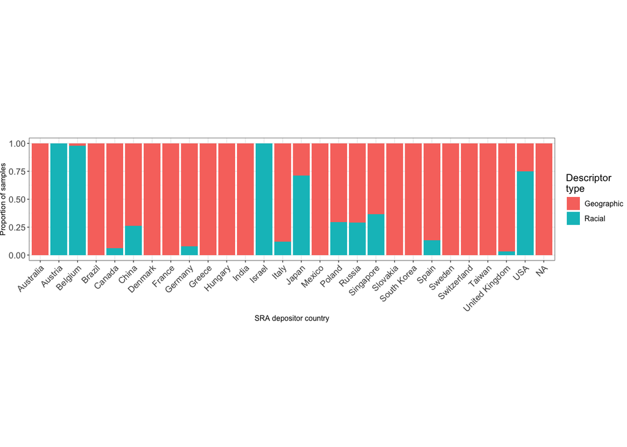

```r
### And finally... does it have any kind of description??
allSRAFinal <- allSRAFinal %>%
  mutate(hasDescriptor = if_else(is.na(strictestRace), "Geographic", "Racial"))

# Easiest to see with a boxplot?
descriptorUsePlot <- ggplot(allSRAFinal, aes(x = finalCountry, fill = hasDescriptor)) +
  geom_bar(position = "fill") +
  ggtitle("") +
  xlab("SRA depositor country") +
  ylab("Proportion of samples") +
  coord_fixed(ratio=6) +
  guides(fill=guide_legend(title="Descriptor\ntype")) +
  theme(axis.text.x = element_text(angle = 45, hjust=1))

descriptorUsePlot
```

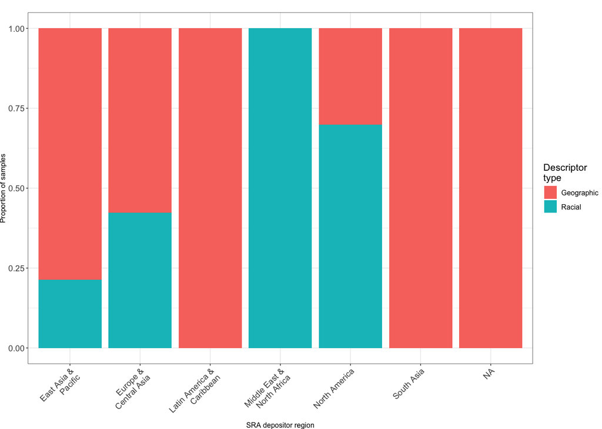

```r
ggsave("fig2_descriptor_use.pdf")
descriptorUseRegionPlot <- ggplot(allSRAFinal, aes(x = worldRegion, fill = hasDescriptor)) +
  geom_bar(position = "fill") +
  ggtitle("") +
  xlab("SRA depositor region") +
  ylab("Proportion of samples") +
  guides(fill=guide_legend(title="Descriptor\ntype")) +
  theme(axis.text.x = element_text(angle = 45, hjust=1))

descriptorUseRegionPlot
```

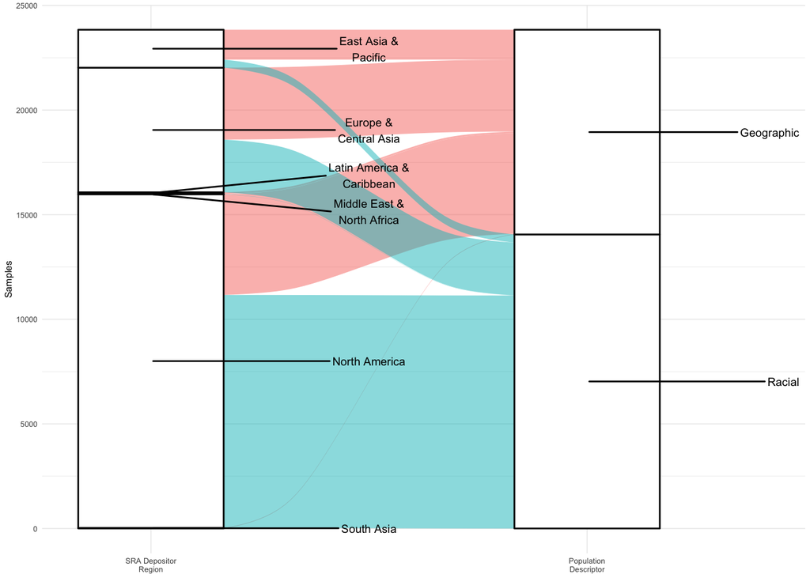

```r
ggsave("fig2_descriptor_use_region_plot.pdf")
descriptorUseRegionAlluvial <- allSRAFinal %>% count(hasDescriptor, worldRegion) %>% drop_na(c(hasDescriptor, worldRegion)) %>%
  ggplot(data = .,
         aes(axis1 = worldRegion, axis2 = hasDescriptor, y = n)) +
    scale_x_discrete(limits = c("SRA Depositor\nRegion", "Population\nDescriptor"), expand = c(.2, .05)) +
    geom_alluvium(aes(fill = hasDescriptor)) +
    geom_stratum(width=1/3) +
    ylab("Samples") +
    geom_text_repel(stat = "stratum", aes(label = after_stat(stratum)), size = 2.5, direction = "y", nudge_x = .5) +
    theme_minimal(base_size = 6) +
    theme(legend.position = "none")

descriptorUseRegionAlluvial
```

```r
ggsave("fig2_descriptor_use_region_alluvial.pdf")
```

And now, some statistics from the figures above:

```r
allSRAFinal %>% count(finalCountry, hasDescriptor) %>%
  group_by(finalCountry) %>%
  mutate(percent = 100 * n/sum(n)) %>%
  ungroup %>%
  as.data.frame()
```

```
##      finalCountry hasDescriptor     n    percent
## 1       Australia    Geographic   126 100.000000
## 2         Austria        Racial     8 100.000000
## 3         Belgium    Geographic    56   2.320763
## 4         Belgium        Racial  2357  97.679237
## 5          Brazil    Geographic    57 100.000000
## 6          Canada    Geographic  1072  93.706294
## 7          Canada        Racial    72   6.293706
## 8           China    Geographic   343  73.922414
## 9           China        Racial   121  26.077586
## 10        Denmark    Geographic   124 100.000000
## 11         France    Geographic     3 100.000000
## 12        Germany    Geographic    72  92.307692
## 13        Germany        Racial     6   7.692308
## 14         Greece    Geographic    28 100.000000
```

[output cut: 26 more lines]

```r
allSRAFinal %>% filter(!grepl('USA', finalCountry)) %>%
  count(hasDescriptor) %>%
  mutate(freq = n/sum(n))
```

```
##   hasDescriptor    n      freq
## 1    Geographic 6087 0.6706699
## 2        Racial 2989 0.3293301
```

```r
allSRAFinal %>% filter(grepl('USA', finalCountry)) %>%
  count(hasDescriptor) %>%
  mutate(freq = n/sum(n))
```

```
##   hasDescriptor     n      freq
## 1    Geographic  3738 0.2524993
## 2        Racial 11066 0.7475007
```

```r
descriptorChi <- full_join((allSRAFinal %>% filter(!grepl('USA', finalCountry)) %>%
  count(hasDescriptor) %>%
  mutate(freq = n/sum(n))),
  (allSRAFinal %>% filter(grepl('USA', finalCountry)) %>%
  count(hasDescriptor) %>%
  mutate(freq = n/sum(n))), by = "hasDescriptor", suffix = c("noUSA", "USA"))

chisq.test(descriptorChi[,c(2,4)])
```

```
##
##  Pearson's Chi-squared test with Yates' continuity correction
##
## data:  descriptorChi[, c(2, 4)]
## X-squared = 4061.3, df = 1, p-value < 2.2e-16
```

```r
allSRAFinal %>% count(hasDescriptor) %>%
  mutate(freq = n/sum(n))
```

```
##   hasDescriptor     n      freq
## 1    Geographic  9825 0.4114322
## 2        Racial 14055 0.5885678
```

```r
# We also want to know the mean sample size of studies in the USA vs those not in the USA, for funsies
usaSizes <- allSRAFinal %>% filter(grepl('USA', finalCountry)) %>%
  group_by(SRA.Study) %>%
  summarise(n = n())
mean(usaSizes$n)
```

```
## [1] 103.5245
```

```r
nousaSizes <- allSRAFinal %>% filter(!grepl('USA', finalCountry)) %>%
  group_by(SRA.Study) %>%
  summarise(n = n())
mean(nousaSizes$n)
```

```
## [1] 76.91525
```

```r
t.test(usaSizes$n, nousaSizes$n)
```

```
##
##  Welch Two Sample t-test
##
## data:  usaSizes$n and nousaSizes$n
## t = 1.2117, df = 258.91, p-value = 0.2267
## alternative hypothesis: true difference in means is not equal to 0
## 95 percent confidence interval:
##  -16.63314  69.85159
## sample estimates:
## mean of x mean of y
## 103.52448  76.91525
```